# A Gentle Introduction

Check the comments in the code snippet to see what each line does!

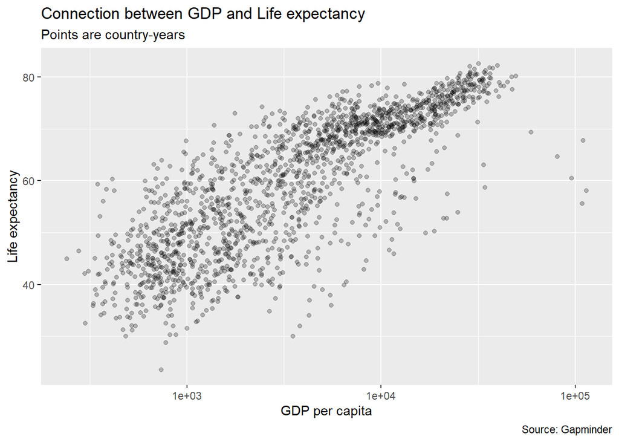

```r
ggplot(data = gapminder_df,
       mapping = aes(x = gdpPercap,
                     y = lifeExp)) +
  geom_point(alpha = 0.25) + # inside the geom_ we can modify its attributes. Here we set the transparency levels of the points
  scale_x_log10() + # rescale our x axis
  labs(x = "GDP per capita",
       y = "Life expectancy",
       title = "Connection between GDP and Life expectancy",
       subtitle = "Points are country-years",
       caption = "Source: Gapminder")
```

So far so good. With some minor additions the plot looks all right. But what if we want to see how each continent fares in this relationship? We need to change the `p1` object to include a new argument in the mapping function: `color = variable`. Now it is clear that European countries (country-years) are clustered in the high-GDP/high life longevity upper right corner.

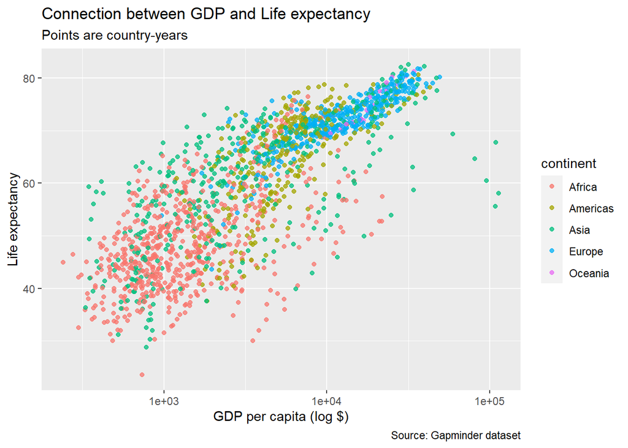

```r
ggplot(data = gapminder_df,
       mapping = aes(x = gdpPercap,
                     y = lifeExp,
                     color = continent)) + # this is where we specify that we want to color the data by continents.
  geom_point(alpha = 0.75) +
  scale_x_log10() + # rescale our x axis
  labs(x = "GDP per capita (log $)",
       y = "Life expectancy",
       title = "Connection between GDP and Life expectancy",
       subtitle = "Points are country-years",
       caption = "Source: Gapminder dataset")
```

When we are done with our nice figure, we can save it as well. I’d suggest to always save with code, and never from the “plots” pane on the right.

```r
ggsave("gapminder_scatter.png", dpi = 600) # the higher the dpi, the smoother your plot'll look like.
```

We can see how life expectancy changed in Mexico, Afghanistan, Sudan and Slovenia by using the `geom_line()` geom. For this, we create a new dataset by subsetting the gapminder one. The `%in%` operator does the same thing as the `==` but for multiple values. For subsetting we use the `dplyr::filter()` function. Don’t worry if this sounds too much, we will spend a whole session on how to subset and clean our data.

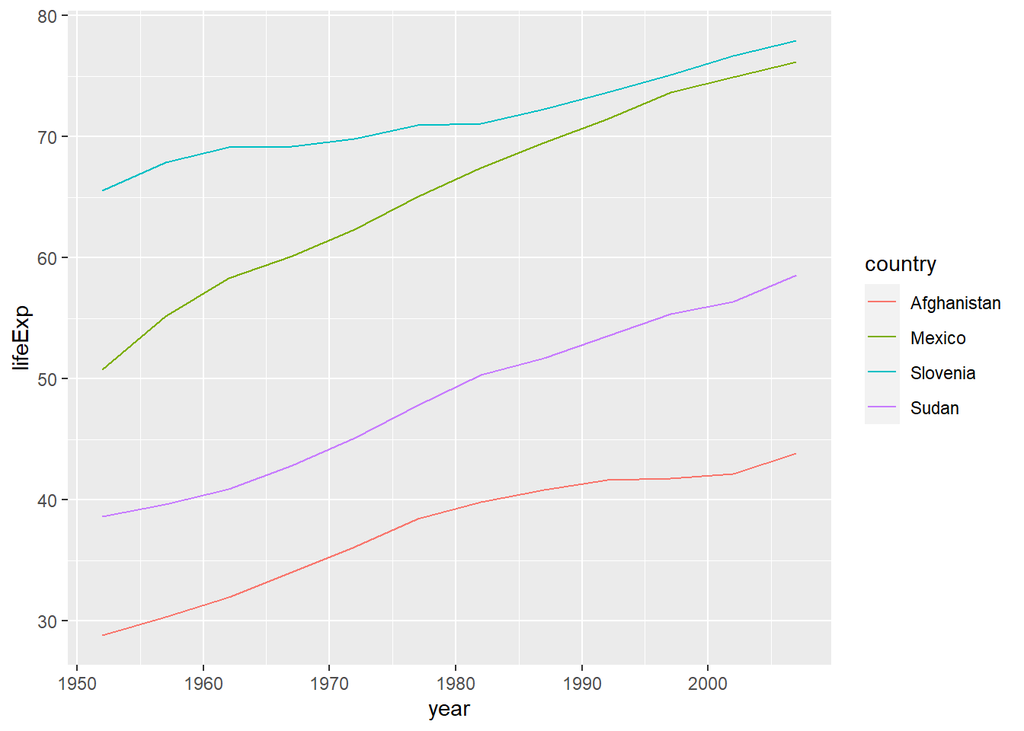

```r
#subset the dataset to have our selected countries.
comp_df <- gapminder_df %>%
    filter(country %in% c("Mexico", "Afghanistan", "Sudan", "Slovenia"))
# create the ggplot object with the data and mapping info
ggplot(data = comp_df,
                  mapping = aes(x = year,
                                y = lifeExp,
                                color = country)) +
  geom_line(aes(group = country)) # we need to tell ggplot that we want to group our lines by countries
```

`ggplot2` makes it easy to create individual subplots for each category by “faceting” our data. Let’s plot the growth in life expectancy over time on each continent. We use the `geom_line()` function to draw a line and we tell ggplot to facet by adding the `facet_wrap(~ variable)` function.

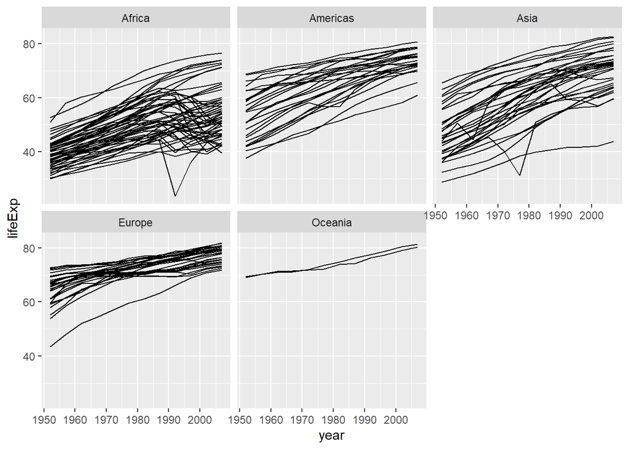

```r
ggplot(data = gapminder_df,
                  mapping = aes(x = year,
                                y = lifeExp)) +
  geom_line(aes(group = country)) + # we need to tell ggplot that we want to group our lines by countries
  facet_wrap(~ continent) # create a small graph for each continent
```